# Session 2: Homework 1

Group 5 Homework 1

26th September 2021

# 1 Where Do People Drink The Most Beer, Wine And Spirits?

Back in 2014, [fivethiryeight.com](https://fivethirtyeight.com/features/dear-mona-followup-where-do-people-drink-the-most-beer-wine-and-spirits/) published an article on alchohol consumption in different countries. The data `drinks` is available as part of the `fivethirtyeight` package. Make sure you have installed the `fivethirtyeight` package before proceeding.

```r
library(fivethirtyeight)
data(drinks)

# or download directly
# alcohol_direct <- read_csv("https://raw.githubusercontent.com/fivethirtyeight/data/master/alcohol-consumption/drinks.csv")
```

What are the variable types? Any missing values we should worry about?

```r
glimpse(drinks)
```

```
## Rows: 193
## Columns: 5
## $ country                      <chr> "Afghanistan", "Albania", "Algeria", "And~
## $ beer_servings                <int> 0, 89, 25, 245, 217, 102, 193, 21, 261, 2~
## $ spirit_servings              <int> 0, 132, 0, 138, 57, 128, 25, 179, 72, 75,~
## $ wine_servings                <int> 0, 54, 14, 312, 45, 45, 221, 11, 212, 191~
## $ total_litres_of_pure_alcohol <dbl> 0.0, 4.9, 0.7, 12.4, 5.9, 4.9, 8.3, 3.8, ~
```

```r
skimr::skim(drinks)
```

Data summary

| Name | drinks |
| --- | --- |
| Number of rows | 193 |
| Number of columns | 5 |
| _______________________ |  |
| Column type frequency: |  |
| character | 1 |
| numeric | 4 |
| ________________________ |  |
| Group variables | None |

**Variable type: character**

| skim_variable | n_missing | complete_rate | min | max | empty | n_unique | whitespace |
| --- | --- | --- | --- | --- | --- | --- | --- |
| country | 0 | 1 | 3 | 28 | 0 | 193 | 0 |

**Variable type: numeric**

| skim_variable | n_missing | complete_rate | mean | sd | p0 | p25 | p50 | p75 | p100 | hist |
| --- | --- | --- | --- | --- | --- | --- | --- | --- | --- | --- |
| beer_servings | 0 | 1 | 106.16 | 101.14 | 0 | 20.0 | 76.0 | 188.0 | 376.0 | ▇▃▂▂▁ |
| spirit_servings | 0 | 1 | 80.99 | 88.28 | 0 | 4.0 | 56.0 | 128.0 | 438.0 | ▇▃▂▁▁ |
| wine_servings | 0 | 1 | 49.45 | 79.70 | 0 | 1.0 | 8.0 | 59.0 | 370.0 | ▇▁▁▁▁ |
| total_litres_of_pure_alcohol | 0 | 1 | 4.72 | 3.77 | 0 | 1.3 | 4.2 | 7.2 | 14.4 | ▇▃▅▃▁ |

```r
#There are five variables in the dataset, namely, country, beer_servings, spirit_servings, wine_servings and total_litres_of_pure_alcohol. Country is a character while beer_servings, spirit_servings, and wine_servings are integers and total_litres_of_pure_alcohol is a double class variable.

#After reviewing the dataset we have come to a conclusion that there are no missing values that we should worry about based on n_missing being 0 for all the variables.
```

Make a plot that shows the top 25 beer consuming countries

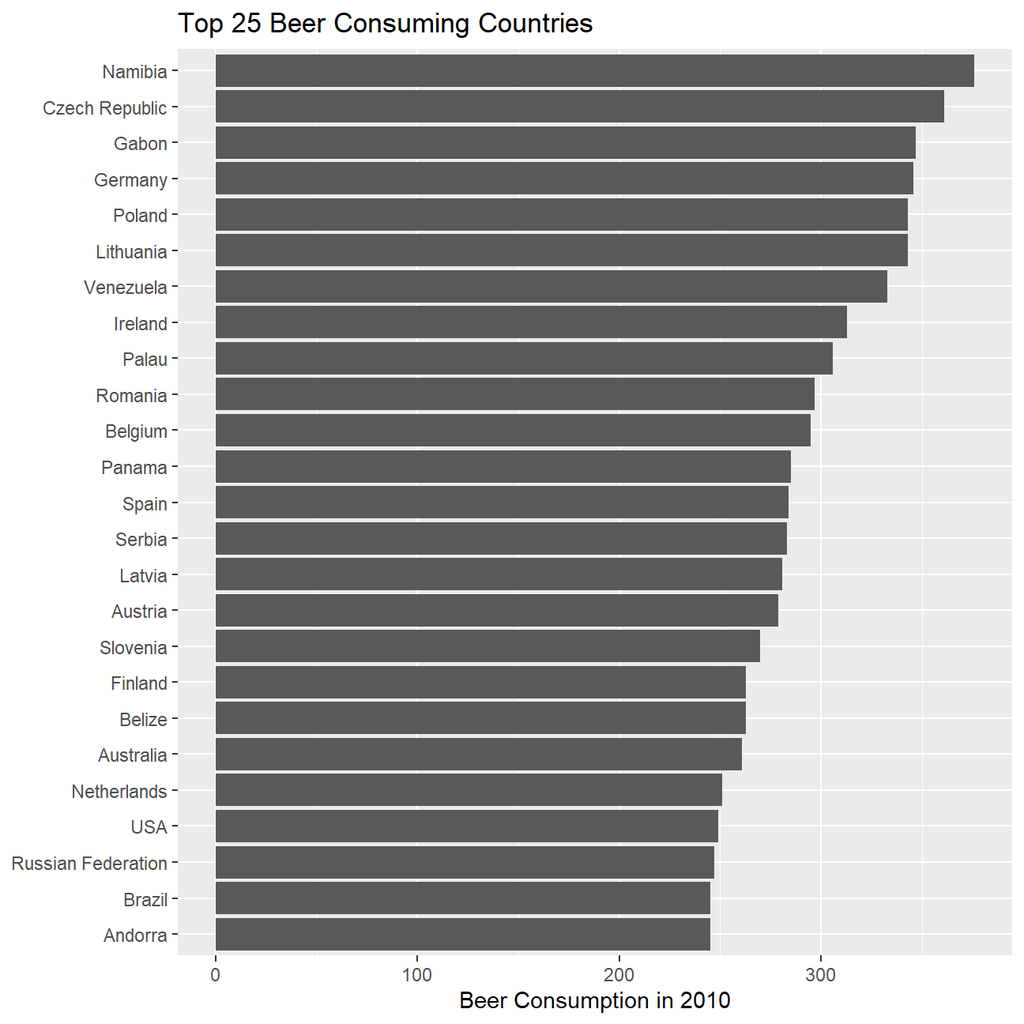

```r
drinks %>%
  slice_max(order_by = beer_servings, n=25) %>%
  ggplot(aes(x = beer_servings, y = fct_reorder(country, beer_servings))) +
  geom_col()+
  labs(title="Top 25 Beer Consuming Countries",
     x="Beer Consumption in 2010",
     y=NULL)+
  NULL
```

```r
# We have used the slicemax function along in tandem with order_by function to extract the top 25 countries based on beer consumption. After extraction we have used the ggplot function along with the fct_reorder function to plot the top 25 beer consuming countries in descending order.
```

Make a plot that shows the top 25 wine consuming countries

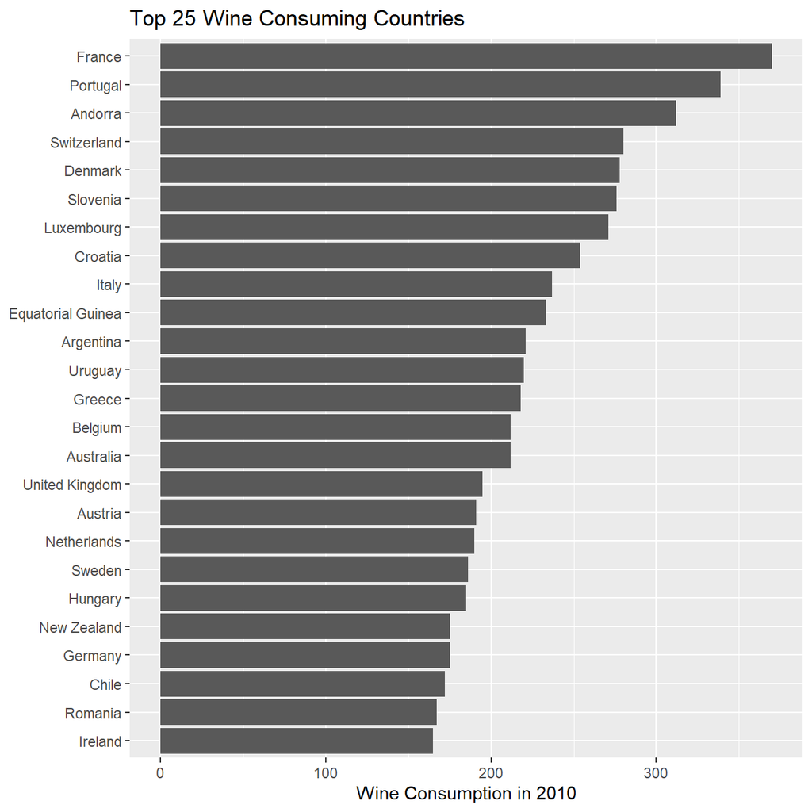

```r
drinks %>%
  slice_max(order_by = wine_servings, n=25) %>%
  ggplot(aes(x = wine_servings, y = fct_reorder(country, wine_servings))) +
  geom_col()+
  labs(title="Top 25 Wine Consuming Countries",
     x="Wine Consumption in 2010",
     y=NULL)+
  NULL
```

```r
# We have used the slicemax function along in tandem with order_by function to extract the top 25 countries based on wine consumption. After extraction we have used the ggplot function along with the fct_reorder function to plot the top 25 wine consuming countries in descending order.
```

Finally, make a plot that shows the top 25 spirit consuming countries

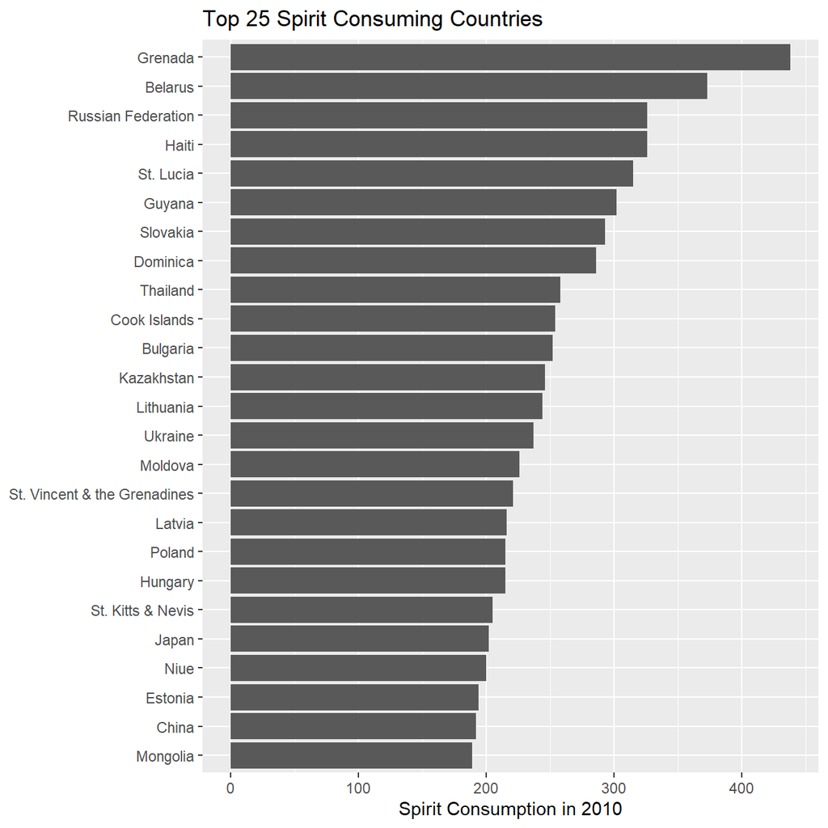

```r
drinks %>%
  slice_max(order_by = spirit_servings, n=25) %>%
  ggplot(aes(x = spirit_servings, y = fct_reorder(country, spirit_servings))) +
  geom_col()+
  labs(title="Top 25 Spirit Consuming Countries",
     x="Spirit Consumption in 2010",
     y=NULL)+
  NULL
```

```r
# We have used the slicemax function along in tandem with order_by function to extract the top 25 countries based on spirit consumption. After extraction we have used the ggplot function along with the fct_reorder function to plot the top 25 spirit consuming countries in descending order.
```

What can you infer from these plots? Don’t just explain what’s in the graph, but speculate or tell a short story (1-2 paragraphs max).

> TYPE YOUR ANSWER AFTER (AND OUTSIDE!) THIS BLOCKQUOTE.

We can infer from these graphs that countries can be classified into three different categories based on their preference of drinks. This is demonstrated through the graphs as none of the top 5 countries for each drink are the same.

# 2 Analysis of movies- IMDB dataset

We will look at a subset sample of movies, taken from the [Kaggle IMDB 5000 movie dataset](https://www.kaggle.com/carolzhangdc/imdb-5000-movie-dataset)

```r
# load the dataset
movies <- read_csv(here::here("data","movies.csv"))
```

Besides the obvious variables of `title`, `genre`, `director`, `year`, and `duration`, the rest of the variables are as follows:

- `gross` : The gross earnings in the US box office, not adjusted for inflation
- `budget`: The movie’s budget
- `cast_facebook_likes`: the number of facebook likes cast memebrs received
- `votes`: the number of people who voted for (or rated) the movie in IMDB
- `reviews`: the number of reviews for that movie
- `rating`: IMDB average rating

## 2.1 Use your data import, inspection, and cleaning skills to answer the following:

- Are there any missing values (NAs)? Are all entries distinct or are there duplicate entries?

```r
# just take a look at the dataset
glimpse(movies)
```

```
## Rows: 2,961
## Columns: 11
## $ title               <chr> "Avatar", "Titanic", "Jurassic World", "The Avenge~
## $ genre               <chr> "Action", "Drama", "Action", "Action", "Action", "~
## $ director            <chr> "James Cameron", "James Cameron", "Colin Trevorrow~
## $ year                <dbl> 2009, 1997, 2015, 2012, 2008, 1999, 1977, 2015, 20~
## $ duration            <dbl> 178, 194, 124, 173, 152, 136, 125, 141, 164, 93, 1~
## $ gross               <dbl> 7.61e+08, 6.59e+08, 6.52e+08, 6.23e+08, 5.33e+08, ~
## $ budget              <dbl> 2.37e+08, 2.00e+08, 1.50e+08, 2.20e+08, 1.85e+08, ~
## $ cast_facebook_likes <dbl> 4834, 45223, 8458, 87697, 57802, 37723, 13485, 920~
## $ votes               <dbl> 886204, 793059, 418214, 995415, 1676169, 534658, 9~
## $ reviews             <dbl> 3777, 2843, 1934, 2425, 5312, 3917, 1752, 1752, 35~
## $ rating              <dbl> 7.9, 7.7, 7.0, 8.1, 9.0, 6.5, 8.7, 7.5, 8.5, 7.2, ~
```

```r
# the skim function from skimr package can give us a more detailed overview
skim(movies)
```

Data summary

| Name | movies |
| --- | --- |
| Number of rows | 2961 |
| Number of columns | 11 |
| _______________________ |  |
| Column type frequency: |  |
| character | 3 |
| numeric | 8 |
| ________________________ |  |
| Group variables | None |

**Variable type: character**

| skim_variable | n_missing | complete_rate | min | max | empty | n_unique | whitespace |
| --- | --- | --- | --- | --- | --- | --- | --- |
| title | 0 | 1 | 1 | 83 | 0 | 2907 | 0 |
| genre | 0 | 1 | 5 | 11 | 0 | 17 | 0 |
| director | 0 | 1 | 3 | 32 | 0 | 1366 | 0 |

**Variable type: numeric**

| skim_variable | n_missing | complete_rate | mean | sd | p0 | p25 | p50 | p75 | p100 | hist |
| --- | --- | --- | --- | --- | --- | --- | --- | --- | --- | --- |
| year | 0 | 1 | 2.00e+03 | 9.95e+00 | 1920.0 | 2.00e+03 | 2.00e+03 | 2.01e+03 | 2.02e+03 | ▁▁▁▂▇ |
| duration | 0 | 1 | 1.10e+02 | 2.22e+01 | 37.0 | 9.50e+01 | 1.06e+02 | 1.19e+02 | 3.30e+02 | ▃▇▁▁▁ |
| gross | 0 | 1 | 5.81e+07 | 7.25e+07 | 703.0 | 1.23e+07 | 3.47e+07 | 7.56e+07 | 7.61e+08 | ▇▁▁▁▁ |
| budget | 0 | 1 | 4.06e+07 | 4.37e+07 | 218.0 | 1.10e+07 | 2.60e+07 | 5.50e+07 | 3.00e+08 | ▇▂▁▁▁ |
| cast_facebook_likes | 0 | 1 | 1.24e+04 | 2.05e+04 | 0.0 | 2.24e+03 | 4.60e+03 | 1.69e+04 | 6.57e+05 | ▇▁▁▁▁ |
| votes | 0 | 1 | 1.09e+05 | 1.58e+05 | 5.0 | 1.99e+04 | 5.57e+04 | 1.33e+05 | 1.69e+06 | ▇▁▁▁▁ |
| reviews | 0 | 1 | 5.03e+02 | 4.94e+02 | 2.0 | 1.99e+02 | 3.64e+02 | 6.31e+02 | 5.31e+03 | ▇▁▁▁▁ |
| rating | 0 | 1 | 6.39e+00 | 1.05e+00 | 1.6 | 5.80e+00 | 6.50e+00 | 7.10e+00 | 9.30e+00 | ▁▁▆▇▁ |

```r
# we check for duplicated entries, if so the result will be at least 1
sum(duplicated(movies))
```

```
## [1] 0
```

From the table above we can find that the values in ‘n_missing’ column is all 0, meaning that there are no missing values.

There are duplicated titles in the database, since we have 2961 rows but only 2907 unique titles according to the ‘n_unique’ column in the above table. However, there are no duplicated entries although there are same titles, since the sum of duplicated movies equals to 0.

- Produce a table with the count of movies by genre, ranked in descending order

```r
movies %>%
  # first we should group the movies by genre
  group_by(genre) %>%
  # then we use the count function to count the numbers by genre, and we set the sort argument as TRUE to rank it in descending order
  count(sort=TRUE)
```

```
## # A tibble: 17 x 2
## # Groups:   genre [17]
##    genre           n
##    <chr>       <int>
##  1 Comedy        848
##  2 Action        738
##  3 Drama         498
##  4 Adventure     288
##  5 Crime         202
##  6 Biography     135
##  7 Horror        131
##  8 Animation      35
##  9 Fantasy        28
## 10 Documentary    25
## 11 Mystery        16
## 12 Sci-Fi          7
## 13 Family          3
## 14 Musical         2
## 15 Romance         2
## 16 Western         2
## 17 Thriller        1
```

- Produce a table with the average gross earning and budget (`gross` and `budget`) by genre. Calculate a variable `return_on_budget` which shows how many $ did a movie make at the box office for each $ of its budget. Ranked genres by this `return_on_budget` in descending order

```r
movies %>%
  # first we still need to group the movies by genre
  group_by(genre) %>%
  # then we need to get the statistics using the summarise function
  summarise(
    average_gross=mean(gross),
    average_budget=mean(budget)
  ) %>%
  # then we add a new column of ROB using mutate function
  mutate(
    return_on_budget=average_gross/average_budget) %>%
  # rank the results using arrange function
  arrange(
    desc(return_on_budget))
```

```
## # A tibble: 17 x 4
##    genre       average_gross average_budget return_on_budget
##    <chr>               <dbl>          <dbl>            <dbl>
##  1 Musical         92084000        3189500          28.9
##  2 Family         149160478.      14833333.         10.1
##  3 Western         20821884        3465000           6.01
##  4 Documentary     17353973.       5887852.          2.95
##  5 Horror          37713738.      13504916.          2.79
##  6 Fantasy         42408841.      17582143.          2.41
##  7 Comedy          42630552.      24446319.          1.74
##  8 Mystery         67533021.      39218750           1.72
##  9 Animation       98433792.      61701429.          1.60
## 10 Biography       45201805.      28543696.          1.58
## 11 Adventure       95794257.      66290069.          1.45
## 12 Drama           37465371.      26242933.          1.43
## 13 Crime           37502397.      26596169.          1.41
## 14 Romance         31264848.      25107500           1.25
## 15 Action          86583860.      71354888.          1.21
## 16 Sci-Fi          29788371.      27607143.          1.08
## 17 Thriller            2468         300000           0.00823
```

- Produce a table that shows the top 15 directors who have created the highest gross revenue in the box office. Don’t just show the total gross amount, but also the mean, median, and standard deviation per director.

```r
movies %>%
  # now we should group the dataset by director
  group_by(director) %>%
  # then we calculate the statistics of movies for every director, note that we divide them by 1 million to make it easier to read
  summarise(
    sum_gross=sum(gross)/1000000,
    mean=mean(gross)/1000000,
    median=median(gross)/1000000,
    sd=sd(gross)/1000000) %>%
  # then we use arrange function to rank the directors according to the total gross revenue they made
  arrange(desc(sum_gross)) %>%
  # just leave the top15 directors that have the highest total gross amount
  head(15)
```

```
## # A tibble: 15 x 5
##    director          sum_gross  mean median    sd
##    <chr>                 <dbl> <dbl>  <dbl> <dbl>
##  1 Steven Spielberg      4014. 175.   164.  101.
##  2 Michael Bay           2231. 172.   138.  127.
##  3 Tim Burton            2071. 129.    76.5 109.
##  4 Sam Raimi             2015. 201.   235.  162.
##  5 James Cameron         1910. 318.   176.  309.
##  6 Christopher Nolan     1813. 227.   197.  187.
##  7 George Lucas          1741. 348.   380.  146.
##  8 Robert Zemeckis       1619. 125.   101.   91.3
##  9 Clint Eastwood        1378.  72.5   46.7  75.5
## 10 Francis Lawrence      1359. 272.   282.  135.
## 11 Ron Howard            1336. 111.   102.   81.9
## 12 Gore Verbinski        1330. 190.   123.  154.
## 13 Andrew Adamson        1137. 284.   280.  121.
## 14 Shawn Levy            1130. 103.    85.5  65.5
## 15 Ridley Scott          1129.  80.6   47.8  68.8
```

- Finally, ratings. Produce a table that describes how ratings are distributed by genre. We don’t want just the mean, but also, min, max, median, SD and some kind of a histogram or density graph that visually shows how ratings are distributed.

```r
movies %>%
  #Let's group movies by genre
  group_by(genre) %>%
  #Then we summarize mean, min, max, sd of ratings by genre
  summarise(mean=mean(rating),
            min=min(rating),
            max=max(rating),
            sd=sd(rating)) %>%
  #Then we arrange all genres in descending order by mean
  arrange(desc(mean))
```

```
## # A tibble: 17 x 5
##    genre        mean   min   max     sd
##    <chr>       <dbl> <dbl> <dbl>  <dbl>
##  1 Biography    7.11   4.5   8.9  0.760
##  2 Crime        6.92   4.8   9.3  0.849
##  3 Mystery      6.86   4.6   8.5  0.882
##  4 Musical      6.75   6.3   7.2  0.636
##  5 Drama        6.73   2.1   8.8  0.917
##  6 Documentary  6.66   1.6   8.5  1.77
##  7 Sci-Fi       6.66   5     8.2  1.09
##  8 Animation    6.65   4.5   8    0.968
##  9 Romance      6.65   6.2   7.1  0.636
## 10 Adventure    6.51   2.3   8.6  1.09
## 11 Family       6.5    5.7   7.9  1.22
## 12 Action       6.23   2.1   9    1.03
## 13 Fantasy      6.15   4.3   7.9  0.959
## 14 Comedy       6.11   1.9   8.8  1.02
## 15 Horror       5.83   3.6   8.5  1.01
## 16 Western      5.7    4.1   7.3  2.26
## 17 Thriller     4.8    4.8   4.8 NA
```

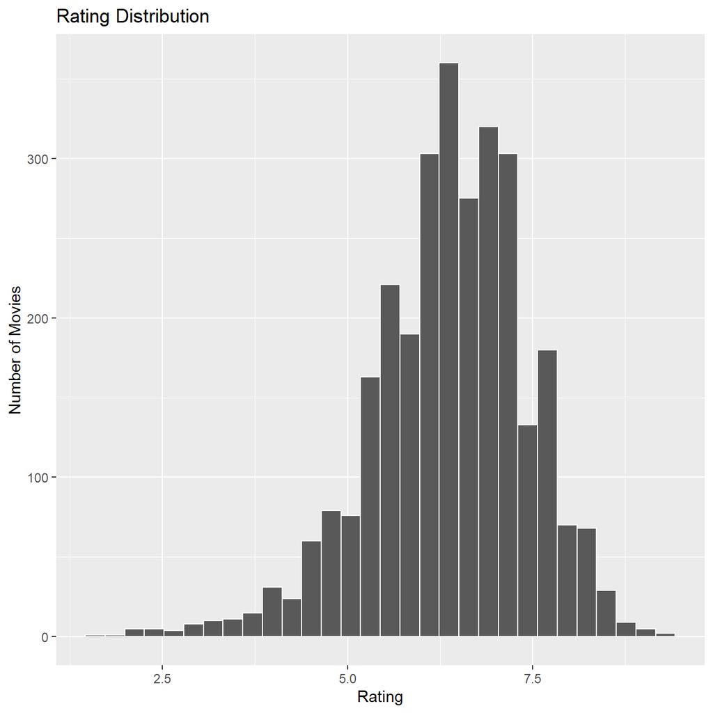

```r
  #Finally, we will produce a histogram showing the distribution of rating
  ggplot(data=movies,mapping=aes(x=rating))+
  labs(title="Rating Distribution", x="Rating", y="Number of Movies")+
  geom_histogram(color="white")
```